# R Notebook

```r
# Loading packages
library(tidyverse)
library(rstanarm)
```

# 10.1

Regression with interactions: Simulate 100 data points from the model, $y = b_0 + b_1 \cdot x + b_2 \cdot z + b_3 \cdot x \cdot z + error$ , with a continuous predictor $x$ and a binary predictor $z$, coefficients $b = (1, 2, -1, -2)$, and errors drawn independently from a normal distribution with mean 0 and standard deviation 3, as follows. For each data point i, first draw $z_i$, equally likely to take on the values 0 and 1. Then draw $x_i$ from a normal distribution with mean $z_i$ and standard deviation 1. Then draw the error from its normal distribution and compute $y_i$.

```r
# defining variables
b <- c(1,2,-1,-2)
b0 <- 1
b1 <- 2
b2 <- -1
b3 <- -2
error <- rnorm(100, mean = 0, sd = 3)
z <- c()
x <- c()
y <- c()

# make for loop
for (i in 1:100){
  # Draw z[i] from rbinom(n=1, size=1, prob=0.5) and put into z
  z[i] <- rbinom(n=1, size=1, prob=0.5)
  # Draw x[i] from rnorm(n=1, mean = z[i], sd = 1)
  x[i] <- rnorm(n=1, mean = z[i], sd = 1)
  # y[i] = b0 + b1*x[i] + b2*z[i] + b3*x[i]*z[i] + error[i]
  y[i] = b0 + b[1]*x[i] + b[2]*z[i] + b[3]*x[i]*z[i] + error[i]
}
simulated_data <- tibble(y = y, x = x, z = z)
```

1. Display your simulated data as a graph og $y$ vs.$x$, using dots and circles for the points with $z = 0$ and 1, respectively

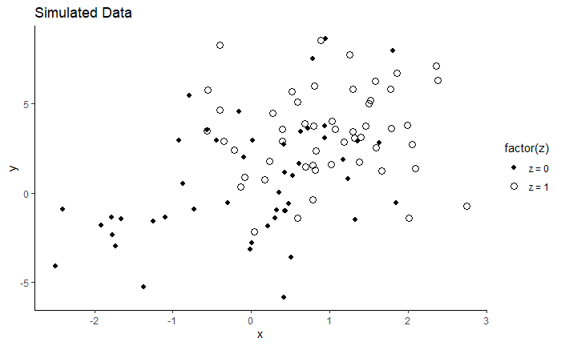

```r
# Create the scatter plot using ggplot2
ggplot(simulated_data, aes(x = x, y = y, shape = factor(z))) +
  geom_point(size = 3) +
  scale_shape_manual(values = c(20, 1), labels = c("z = 0", "z = 1")) +
  labs(title = "Simulated Data", x = "x", y = "y") +
  theme_classic()
```

2. Fit a regression predicting $y$ from $x$ and $z$ with no interaction. Make a graph with the data and the two parallel lines showing the fitted model

```r
set.seed(2)
# Making data frame
M1 <- stan_glm(y ~ x + z, data = simulated_data)
# Extracting coefficient

M1c <- tibble(intercept = M1$coefficients[1], x = M1$coefficients[2], z = M1$coefficients[3])
```

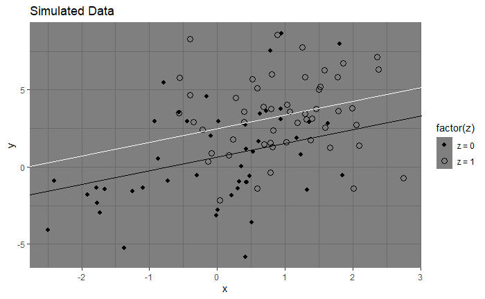

```r
# Making ggplot with two regression lines
ggplot(simulated_data, aes(x = x, y = y, shape = factor(z))) +
  geom_point(size = 3) +
  scale_shape_manual(values = c(20, 1), labels = c("z = 0", "z = 1")) +
  labs(title = "Simulated Data", x = "x", y = "y") +
  theme_dark()+
  geom_abline(aes(intercept = M1$coefficients[1]+M1$coefficients[3], slope = M1$coefficients[2]), color = "white")+
  geom_abline(aes(intercept = M1$coefficients[1], slope = M1$coefficients[2]), color = "Black")
```

```r
NA
```

3. Fit a regression predicting $y$ from $x$, $z$ and their interaction. Make a graph with the data and the two lines showing the fitted model.

```r
set.seed(1)
# Making model
M2 <- stan_glm(y ~ x + z + x:z, data = simulated_data)
coef(M2)
```

```
(Intercept)           x           z         x:z
  0.6495253   1.3037480   2.5055815  -1.1102783
```

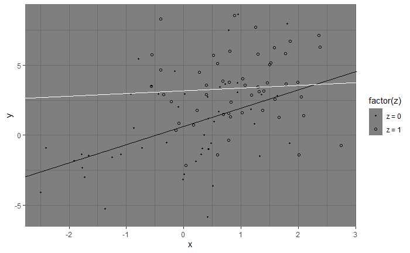

```r
# making graph
simulated_data %>% ggplot(aes(x, y, shape = factor(z)))+
  geom_point()+
  scale_shape_manual(values = c(20, 1), labels = c("z = 0", "z = 1"))+
  theme_dark()+
  geom_abline(aes(intercept = M2$coefficients[1], slope = M2$coefficients[2]), color = "black")+
  geom_abline(aes(intercept = M2$coefficients[1] + M2$coefficients[3], slope = M2$coefficients[2] + M2$coefficients[4]), color = "white")
```

```r
  # Adding different colors




  # Adding different regression lines
```

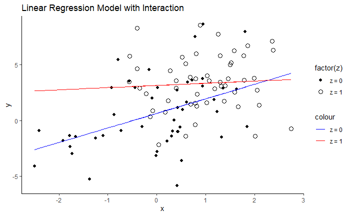

```r
# Extract coefficients
b <- coef(M2)

# Compute predicted y values for z = 0 and z = 1
y_pred_z0 <- b[1] + b[2] * x + b[3] * 0 + b[4] * x * 0
y_pred_z1 <- b[1] + b[2] * x + b[3] * 1 + b[4] * x * 1

# Create the scatter plot using ggplot2
ggplot(simulated_data, aes(x = x, y = y, shape = factor(z))) +
  geom_point(size = 3) +
  geom_line(aes(x = x, y = y_pred_z0, color = "blue")) +
  geom_line(aes(x = x, y = y_pred_z1, color = "red")) +
  scale_shape_manual(values = c(20, 1), labels = c("z = 0", "z = 1")) +
  scale_color_manual(values = c("blue", "red"), labels = c("z = 0", "z = 1")) +
  labs(title = "Linear Regression Model with Interaction", x = "x", y = "y") +
  theme_classic()
```

```r
rm(list = ls())
```